# Excess correlation among U.S. industries

# 1. Main results

## Table 3. Excess correlations across industries

Table 3. Excess correlations across industries

|  | Default risk Default probability | Default risk Default probability ⊥ Equity moments | Default risk Leverage | Default risk Credit spread | Equity moments Excess returns | Equity moments Volatility |
| --- | --- | --- | --- | --- | --- | --- |
| **Panel A: Unrelated industries** |  |  |  |  |  |  |
| Total Correlation | 0.124 | 0.101 | 0.296 | 0.555 | 0.310 | 0.648 |
|  | (0.037) | (0.034) | (0.041) | (0.041) | (0.054) | (0.098) |
| Excess Correlation | 0.116 | 0.110 | 0.193 | 0.340 | 0.194 | 0.463 |
|  | (0.037) | (0.029) | (0.028) | (0.076) | (0.033) | (0.069) |
| **Panel B: All industries** |  |  |  |  |  |  |
| Total Correlation | 0.221 | 0.148 | 0.488 | 0.556 | 0.549 | 0.804 |
|  | (0.061) | (0.030) | (0.042) | (0.063) | (0.043) | (0.053) |
| Excess Correlation | 0.092 | 0.090 | 0.246 | 0.271 | 0.263 | 0.643 |
|  | (0.018) | (0.020) | (0.021) | (0.063) | (0.025) | (0.047) |

# 2. Online Appendix tables

## Table OA.4. Correlations in firm fundamentals among unrelated industries

Table OA.4. Correlations in firm fundamentals among unrelated industries

| Industry pair | Fundamental variables EBITDA | Fundamental variables EARN1Q | Fundamental variables NIMTA | Fundamental variables CASHMTA | Fundamental variables ASSETS | Fundamental variables PROFIT | Fundamental variables SALES |
| --- | --- | --- | --- | --- | --- | --- | --- |
| Food & Smoke | -0.008 | -0.075 | -0.177 | 0.191 | 0.188 | 0.278 | 0.261 |
|  | (0.083) | (0.083) | (0.082) | (0.082) | (0.082) | (0.080) | (0.080) |
| Smoke & MedEq | -0.062 | 0.245 | 0.127 | 0.056 | 0.173 | 0.140 | 0.236 |
|  | (0.083) | (0.081) | (0.082) | (0.083) | (0.082) | (0.082) | (0.081) |
| Smoke & Chems | -0.102 | 0.175 | 0.174 | 0.061 | 0.043 | 0.126 | 0.108 |
|  | (0.083) | (0.082) | (0.082) | (0.083) | (0.083) | (0.082) | (0.083) |
| Smoke & BusSv | -0.028 | -0.174 | -0.004 | -0.033 | 0.123 | 0.085 | 0.107 |
|  | (0.083) | (0.082) | (0.083) | (0.083) | (0.082) | (0.083) | (0.083) |
| Smoke & Chips | 0.008 | -0.067 | -0.127 | 0.051 | -0.011 | 0.106 | 0.066 |
|  | (0.083) | (0.083) | (0.082) | (0.083) | (0.083) | (0.083) | (0.083) |
| Smoke & Paper | -0.045 | 0.304 | 0.103 | 0.102 | 0.144 | 0.047 | 0.053 |
|  | (0.083) | (0.079) | (0.083) | (0.083) | (0.082) | (0.083) | (0.083) |
| Smoke & Trans | -0.134 | 0.177 | 0.114 | 0.081 | -0.008 | -0.089 | 0.025 |
|  | (0.082) | (0.082) | (0.083) | (0.083) | (0.083) | (0.083) | (0.083) |
| Smoke & Whlsl | -0.103 | 0.088 | 0.054 | 0.060 | 0.110 | 0.172 | 0.186 |
|  | (0.083) | (0.083) | (0.083) | (0.083) | (0.083) | (0.082) | (0.082) |
| Toys & Gold | 0.039 | 0.140 | 0.045 | -0.003 | 0.015 | 0.021 | -0.014 |
|  | (0.083) | (0.083) | (0.083) | (0.083) | (0.083) | (0.083) | (0.083) |
| Fun & Ships | -0.030 | -0.146 | 0.029 | 0.164 | -0.059 | -0.011 | -0.096 |
|  | (0.083) | (0.084) | (0.083) | (0.082) | (0.083) | (0.083) | (0.083) |
| Hlth & Gold | 0.003 | -0.086 | -0.159 | -0.129 | 0.046 | -0.012 | -0.021 |
|  | (0.083) | (0.083) | (0.082) | (0.082) | (0.083) | (0.083) | (0.083) |
| Txtls & Ships | -0.064 | 0.039 | 0.062 | 0.124 | 0.033 | -0.112 | 0.071 |
|  | (0.083) | (0.085) | (0.083) | (0.082) | (0.083) | (0.083) | (0.083) |
| Cnstr & Gold | -0.055 | -0.023 | -0.051 | 0.026 | -0.047 | -0.009 | 0.025 |
|  | (0.083) | (0.083) | (0.083) | (0.083) | (0.083) | (0.083) | (0.083) |
| FabPr & Gold | -0.092 | -0.023 | -0.003 | 0.036 | 0.036 | -0.045 | -0.021 |
|  | (0.083) | (0.083) | (0.083) | (0.083) | (0.083) | (0.083) | (0.083) |
| Guns & Gold | -0.017 | 0.021 | -0.114 | -0.041 | 0.054 | 0.148 | 0.219 |
|  | (0.083) | (0.083) | (0.083) | (0.083) | (0.083) | (0.082) | (0.081) |
| Gold & Mines | 0.084 | 0.048 | -0.001 | 0.163 | 0.047 | 0.104 | 0.202 |
|  | (0.083) | (0.083) | (0.083) | (0.082) | (0.083) | (0.083) | (0.081) |
| Gold & Coal | -0.001 | 0.108 | 0.031 | -0.036 | 0.144 | 0.019 | -0.088 |
|  | (0.083) | (0.083) | (0.083) | (0.083) | (0.082) | (0.083) | (0.083) |
| Gold & PerSv | 0.179 | 0.006 | -0.043 | 0.072 | 0.034 | -0.016 | -0.080 |
|  | (0.082) | (0.083) | (0.083) | (0.083) | (0.083) | (0.083) | (0.083) |

## Table OA.5. Correlations in default risk and equity moments among unrelated industries

Table OA.5. Correlations in default risk and equity moments among unrelated industries

| Industry pair | Default risk Default prob. | Default risk Leverage | Default risk Credit Spread | Equity moments Excess return | Equity moments Volatility |
| --- | --- | --- | --- | --- | --- |
| Food & Smoke | 0.403 | 0.614 | 0.757 | 0.709 | 0.637 |
|  | (0.076) | (0.066) | (0.072) | (0.059) | (0.064) |
| Smoke & MedEq | 0.296 | 0.512 | 0.726 | 0.550 | 0.633 |
|  | (0.079) | (0.071) | (0.076) | (0.069) | (0.064) |
| Smoke & Chems | -0.008 | 0.318 | 0.769 | 0.404 | 0.574 |
|  | (0.083) | (0.079) | (0.070) | (0.076) | (0.068) |
| Smoke & BusSv | 0.013 | 0.333 | 0.694 | 0.159 | 0.614 |
|  | (0.083) | (0.078) | (0.079) | (0.082) | (0.066) |
| Smoke & Chips | -0.181 | 0.247 | 0.747 | 0.149 | 0.600 |
|  | (0.082) | (0.080) | (0.073) | (0.082) | (0.066) |
| Smoke & Paper | -0.055 | 0.373 | 0.758 | 0.468 | 0.578 |
|  | (0.083) | (0.077) | (0.072) | (0.073) | (0.068) |
| Smoke & Trans | 0.002 | 0.334 | 0.769 | 0.444 | 0.601 |
|  | (0.083) | (0.078) | (0.070) | (0.074) | (0.066) |
| Smoke & Whlsl | 0.033 | 0.436 | 0.715 | 0.491 | 0.636 |
|  | (0.083) | (0.075) | (0.077) | (0.072) | (0.064) |
| Toys & Gold | 0.020 | 0.107 | 0.338 | 0.038 | 0.631 |
|  | (0.083) | (0.083) | (0.139) | (0.083) | (0.064) |
| Fun & Ships | 0.380 | 0.434 | 0.584 | 0.489 | 0.709 |
|  | (0.077) | (0.075) | (0.109) | (0.072) | (0.059) |
| Hlth & Gold | 0.068 | 0.032 | 0.461 | 0.030 | 0.641 |
|  | (0.083) | (0.083) | (0.125) | (0.083) | (0.064) |
| Txtls & Ships | 0.423 | 0.611 | 0.574 | 0.677 | 0.761 |
|  | (0.075) | (0.066) | (0.130) | (0.061) | (0.054) |
| Cnstr & Gold | 0.093 | 0.141 | 0.408 | 0.107 | 0.712 |
|  | (0.083) | (0.082) | (0.129) | (0.083) | (0.058) |
| FabPr & Gold | 0.038 | 0.118 | -0.021 | 0.106 | 0.606 |
|  | (0.083) | (0.082) | (0.192) | (0.083) | (0.066) |
| Guns & Gold | 0.161 | 0.031 | 0.380 | 0.085 | 0.622 |
|  | (0.082) | (0.083) | (0.133) | (0.083) | (0.065) |
| Gold & Mines | 0.314 | 0.382 | 0.621 | 0.391 | 0.797 |
|  | (0.079) | (0.077) | (0.112) | (0.076) | (0.050) |
| Gold & Coal | 0.123 | 0.297 | 0.289 | 0.278 | 0.657 |
|  | (0.082) | (0.079) | (0.140) | (0.080) | (0.063) |
| Gold & PerSv | 0.106 | 0.005 | 0.428 | 0.013 | 0.646 |
|  | (0.083) | (0.083) | (0.128) | (0.083) | (0.063) |

## Table OA.6. Correlations in firm fundamentals among unrelated industries - Robustness

Table OA.6. Correlations in firm fundamentals among unrelated industries - Robustness

|  | EBITDA | EARN1Q | NIMTA | CASHMTA | ASSETS | PROFIT | SALES |
| --- | --- | --- | --- | --- | --- | --- | --- |
| **Full Sample** |  |  |  |  |  |  |  |
| Frequ. p<5% | 0.056 | 0.278 | 0.056 | 0.167 | 0.222 | 0.222 | 0.278 |
| Average | -0.024 | 0.042 | 0.003 | 0.052 | 0.059 | 0.053 | 0.069 |
|  | (0.024) | (0.022) | (0.018) | (0.026) | (0.027) | (0.023) | (0.029) |
| **Pre-GFC** |  |  |  |  |  |  |  |
| Frequ. p<5% | 0.000 | 0.167 | 0.056 | 0.111 | 0.111 | 0.056 | 0.000 |
| Average | -0.054 | 0.018 | 0.007 | 0.065 | 0.017 | 0.003 | -0.006 |
|  | (0.026) | (0.030) | (0.024) | (0.030) | (0.035) | (0.024) | (0.029) |
| **Post-GFC** |  |  |  |  |  |  |  |
| Frequ. p<5% | 0.222 | 0.167 | 0.111 | 0.056 | 0.111 | 0.167 | 0.500 |
| Average | 0.103 | 0.089 | 0.009 | 0.041 | 0.077 | 0.128 | 0.170 |
|  | (0.033) | (0.027) | (0.033) | (0.041) | (0.038) | (0.031) | (0.040) |
| **Ex-Recessions** |  |  |  |  |  |  |  |
| Frequ. p<5% | 0.056 | 0.222 | 0.056 | 0.167 | 0.167 | 0.167 | 0.278 |
| Average | -0.020 | 0.048 | -0.002 | 0.080 | 0.057 | 0.049 | 0.065 |
|  | (0.033) | (0.026) | (0.017) | (0.024) | (0.033) | (0.028) | (0.032) |
| **Annual** |  |  |  |  |  |  |  |
| Frequ. p<5% | 0.000 | 0.278 | 0.056 | 0.111 | 0.111 | 0.056 | 0.222 |
| Average | -0.059 | 0.103 | 0.100 | 0.078 | 0.079 | 0.034 | 0.102 |
|  | (0.065) | (0.030) | (0.040) | (0.067) | (0.064) | (0.047) | (0.051) |

## Table OA.7. Total and excess correlations among unrelated industries - Robustness

Table OA.7. Total and excess correlations among unrelated industries - Robustness

Default risk

Equity moments

Default prob.

Default prob. ⊥ Equity.

Leverage

Credit spread

Excess return

Volatility

**Panel A: Pre-GFC**

Total Correlation

0.100

0.100

0.270

0.376

0.257

0.503

(0.035)

(0.035)

(0.063)

(0.173)

(0.074)

(0.138)

Excess Correlation

0.100

0.111

0.156

0.157

0.374

(0.033)

(0.025)

(0.038)

(0.047)

(0.092)

**Panel B: Post-GFC**

Total Correlation

0.137

0.182

0.359

0.596

0.409

0.763

(0.072)

(0.039)

(0.045)

(0.039)

(0.051)

(0.083)

Excess Correlation

0.211

0.191

0.242

0.355

0.268

0.435

(0.031)

(0.032)

(0.043)

(0.079)

(0.038)

(0.047)

**Panel C: Ex-Recessions**

Total Correlation

0.117

0.080

0.285

0.499

0.299

0.527

(0.031)

(0.033)

(0.045)

(0.050)

(0.054)

(0.099)

Excess Correlation

0.099

0.087

0.216

0.367

0.225

0.383

(0.034)

(0.027)

(0.026)

(0.056)

(0.032)

(0.070)

**Panel D: Annual Frequency**

Total Correlation

0.245

0.197

0.276

0.691

0.254

0.821

(0.059)

(0.062)

(0.083)

(0.065)

(0.082)

(0.098)

Excess Correlation

0.182

0.161

0.146

0.485

0.125

0.555

(0.040)

(0.056)

(0.044)

(0.119)

(0.050)

(0.065)

## Table OA.8. Total and excess correlations among all industries - Robustness

Table OA.8. Total and excess correlations among all industries - Robustness

Default risk

Equity moments

Default prob.

Default prob. ⊥ Equity.

Leverage

Credit spread

Excess return

Volatility

**Panel A: Pre-GFC**

Total Correlation

0.122

0.116

0.428

0.383

0.499

0.747

(0.029)

(0.034)

(0.056)

(0.077)

(0.059)

(0.095)

Excess Correlation

0.074

0.087

0.222

0.239

0.620

(0.015)

(0.026)

(0.021)

(0.028)

(0.073)

**Panel B: Post-GFC**

Total Correlation

0.370

0.160

0.552

0.552

0.618

0.839

(0.111)

(0.049)

(0.059)

(0.080)

(0.053)

(0.047)

Excess Correlation

0.107

0.088

0.270

0.274

0.309

0.555

(0.040)

(0.036)

(0.033)

(0.062)

(0.032)

(0.035)

**Panel C: Ex-Recessions**

Total Correlation

0.116

0.093

0.428

0.426

0.494

0.747

(0.024)

(0.030)

(0.044)

(0.046)

(0.046)

(0.060)

Excess Correlation

0.080

0.073

0.256

0.324

0.269

0.608

(0.019)

(0.023)

(0.022)

(0.040)

(0.026)

(0.055)

**Panel D: Annual Frequency**

Total Correlation

0.269

0.141

0.429

0.755

0.417

0.894

(0.076)

(0.068)

(0.083)

(0.121)

(0.077)

(0.057)

Excess Correlation

0.111

0.112

0.179

0.574

0.164

0.652

(0.033)

(0.054)

(0.036)

(0.052)

(0.046)

(0.067)

## Table OA.9. Excess correlations comparison across size and book leverage terciles

Table OA.9. Excess correlations comparison across size and book leverage terciles

Default risk

Equity moments

Default probability

Default probability ⊥ Equity moments

Leverage

Credit spread

Excess returns

Volatility

**Panel A: Excess Correlation by Industry Size**

1. Large industries

0.150

0.161

0.316

0.554

0.336

0.739

(0.032)

(0.036)

(0.028)

(0.052)

(0.030)

(0.046)

2. Small industries

0.061

0.057

0.192

0.149

0.214

0.552

(0.016)

(0.018)

(0.024)

(0.053)

(0.025)

(0.047)

(a)-(b) Large minus Small

0.089

0.104

0.123

0.405

0.122

0.187

(0.035)

(0.040)

(0.034)

(0.056)

(0.034)

(0.027)

**Panel B: Excess Correlation by Book Leverage**

3. High-leverage industries

0.067

0.080

0.253

0.333

0.241

0.619

(0.028)

(0.023)

(0.033)

(0.066)

(0.028)

(0.049)

4. Low-leverage industries

0.116

0.111

0.250

0.240

0.267

0.672

(0.024)

(0.026)

(0.028)

(0.055)

(0.027)

(0.052)

(c)-(d) High minus Low

-0.049

-0.031

0.003

0.093

-0.025

-0.054

(0.033)

(0.023)

(0.036)

(0.036)

(0.025)

(0.017)

# 3. Figures

## Figure OA.5. Campbell et al. (2008)’s default probability vs. fitted value

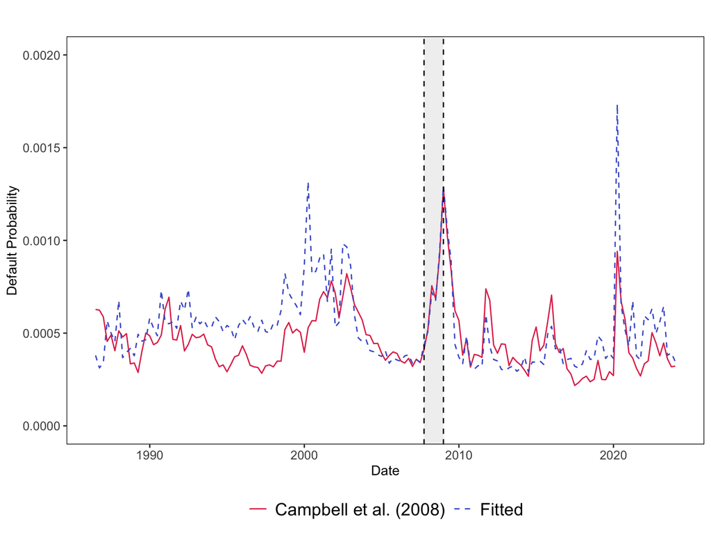

Correlation between Campbell et al. (2008) PROB and fitted value, by subsample

| subsample | corr |
| --- | --- |
| Post-2008 | 0.722 |
| Pre-2009 | 0.629 |